# Ladder memory equations

```python
from fast import *
from fast.config import fast_path
from matplotlib import pyplot
from sympy import sin,cos,exp,sqrt,pi,zeros,I, Integral, oo
from numpy import array
%matplotlib inline
init_printing()
print_ascii=True; print_ascii=False
```

```python
path="/home/oscar/oxford/inhomogeneous_broadening/complete_model/"
name='orca'
```

We will be deriving the optical Bloch equations for a three level system in a ladder configuration as that in the figure.

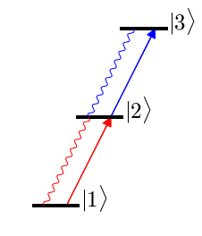

```python
fig=pyplot.figure(); ax=fig.add_subplot(111,aspect="equal")

p1=[0.5,1]; p2=[1.5,3]; p3=[2.5,5]
draw_state(ax,p1,text=r"$|1\rangle$",l=1.0,alignment='right',label_displacement=0.05,fontsize=25,linewidth=4.0)
draw_state(ax,p2,text=r"$|2\rangle$",l=1.0,alignment='right',label_displacement=0.05,fontsize=25,linewidth=4.0)
draw_state(ax,p3,text=r"$|3\rangle$",l=1.0,alignment='right',label_displacement=0.05,fontsize=25,linewidth=4.0)

excitation(ax,[p1[0]+0.25,p1[1]],[p2[0]+0.25,p2[1]], fc="r", ec="r",width=0.01, head_width=0.2, head_length=0.2)
excitation(ax,[p2[0]+0.25,p2[1]],[p3[0]+0.25,p3[1]], fc="b", ec="b",width=0.01, head_width=0.2, head_length=0.2)

decay(     ax,[p1[0]-0.25,p1[1]],[p2[0]-0.25,p2[1]], 0.05,10.0,color="r",linewidth=1.0)
decay(     ax,[p2[0]-0.25,p2[1]],[p3[0]-0.25,p3[1]], 0.05,10.0,color="b",linewidth=1.0)

pyplot.axis('off')
pyplot.savefig(path+name+'_diagram.png',bbox_inches="tight")
```

We define the number of states and of radiation fields.

```python
Ne=3
Nl=2
```

We define a few important symbols.

```python
c,hbar,e,mu0, epsilon0=symbols("c hbar e mu0 varepsilon0",positive=True)
fprint([c,hbar,e,mu0, epsilon0],print_ascii=print_ascii)
```

$$\left [ c, \quad \hbar, \quad e, \quad \mu_{0}, \quad \varepsilon_{0}\right ]$$

```python
t,X,Y,Z,R,Phi=symbols("t X Y Z R Phi",real=True)
RR=Matrix([R*cos(Phi),R*sin(Phi),Z])
#RR=Matrix([X,Y,Z])
fprint([t,RR],print_ascii=print_ascii)
```

$$\left [ t, \quad \left[\begin{matrix}R \cos{\left (\Phi \right )}\\R \sin{\left (\Phi \right )}\\Z\end{matrix}\right]\right ]$$

We define the variables related to the laser field.

```python
E0,omega_laser=define_laser_variables(Nl, variables=[t,R,Z])
fprint(E0,print_ascii=print_ascii)
```

$$\left [ \operatorname{E^{1}_{0}}{\left (t,R,Z \right )}, \quad \operatorname{E^{2}_{0}}{\left (t,R,Z \right )}\right ]$$

```python
fprint(omega_laser,print_ascii=print_ascii)
```

$$\left [ \varpi_{1}, \quad \varpi_{2}\right ]$$

```python
phi1=0 ; theta1=0; alpha1=pi/2; beta1=pi/8
phi2=0; theta2=pi; alpha2=pi/2; beta2=pi/8

k1=Matrix([cos(phi1)*sin(theta1),sin(phi1)*sin(theta1),cos(theta1)])
k2=Matrix([cos(phi2)*sin(theta2),sin(phi2)*sin(theta2),cos(theta2)])

k=[k1,k2]

fprint(k,print_ascii=print_ascii)
```

$$\left [ \left[\begin{matrix}0\\0\\1\end{matrix}\right], \quad \left[\begin{matrix}0\\0\\-1\end{matrix}\right]\right ]$$

The polarization vectors.

```python
ep1=polarization_vector(phi1,theta1,alpha1,beta1, 1)
ep2=polarization_vector(phi2,theta2,alpha2,beta2, 1)

em1=ep1.conjugate()
em2=ep2.conjugate()

ep=[ep1,ep2]
em=[em1,em2]

fprint([ep,em],print_ascii=print_ascii)
```

$$\left [ \left [ \left[\begin{matrix}- \frac{\sqrt{2}}{2}\\- \frac{\sqrt{2} i}{2}\\0\end{matrix}\right], \quad \left[\begin{matrix}\frac{\sqrt{2}}{2}\\- \frac{\sqrt{2} i}{2}\\0\end{matrix}\right]\right ], \quad \left [ \left[\begin{matrix}- \frac{\sqrt{2}}{2}\\\frac{\sqrt{2} i}{2}\\0\end{matrix}\right], \quad \left[\begin{matrix}\frac{\sqrt{2}}{2}\\\frac{\sqrt{2} i}{2}\\0\end{matrix}\right]\right ]\right ]$$

```python
zero_vect=Matrix([0,0,0])
E_cartesian = [(+E0[l]            *ep[l]*exp(-I*omega_laser[l]*(t-k[l].dot(RR)/c))
                +E0[l].conjugate()*em[l]*exp(+I*omega_laser[l]*(t-k[l].dot(RR)/c)))/2
                    for l in range(Nl)]

fprint(E_cartesian,print_ascii=print_ascii)
```

$$\left [ \left[\begin{matrix}- \frac{\sqrt{2}}{4} \operatorname{E^{1}_{0}}{\left (t,R,Z \right )} e^{- i \varpi_{1} \left(- \frac{Z}{c} + t\right)} - \frac{\sqrt{2}}{4} e^{i \varpi_{1} \left(- \frac{Z}{c} + t\right)} \overline{\operatorname{E^{1}_{0}}{\left (t,R,Z \right )}}\\- \frac{\sqrt{2} i}{4} \operatorname{E^{1}_{0}}{\left (t,R,Z \right )} e^{- i \varpi_{1} \left(- \frac{Z}{c} + t\right)} + \frac{\sqrt{2} i}{4} e^{i \varpi_{1} \left(- \frac{Z}{c} + t\right)} \overline{\operatorname{E^{1}_{0}}{\left (t,R,Z \right )}}\\0\end{matrix}\right], \quad \left[\begin{matrix}\frac{\sqrt{2}}{4} \operatorname{E^{2}_{0}}{\left (t,R,Z \right )} e^{- i \varpi_{2} \left(\frac{Z}{c} + t\right)} + \frac{\sqrt{2}}{4} e^{i \varpi_{2} \left(\frac{Z}{c} + t\right)} \overline{\operatorname{E^{2}_{0}}{\left (t,R,Z \right )}}\\- \frac{\sqrt{2} i}{4} \operatorname{E^{2}_{0}}{\left (t,R,Z \right )} e^{- i \varpi_{2} \left(\frac{Z}{c} + t\right)} + \frac{\sqrt{2} i}{4} e^{i \varpi_{2} \left(\frac{Z}{c} + t\right)} \overline{\operatorname{E^{2}_{0}}{\left (t,R,Z \right )}}\\0\end{matrix}\right]\right ]$$

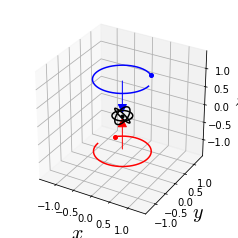

```python
l1=PlaneWave(phi1,theta1,alpha1,beta1,color="red")
l2=PlaneWave(phi2,theta2,alpha2,beta2,color="blue")

laseres=[l1,l2]
Nl=len(laseres)

fig = pyplot.figure(); ax = fig.gca(projection='3d')
draw_lasers_3d(ax,laseres,path+name+'_lasers.png')
```

We write the electric fields in the helicity basis (see notebook "Vectors in the helicity basis and the electric field").

```python
E=[cartesian_to_helicity(E_cartesian[l]).expand() for l in range(Nl)]
fprint(E,print_ascii=print_ascii)
```

$$\left [ \left[\begin{matrix}- \frac{1}{2} \operatorname{E^{1}_{0}}{\left (t,R,Z \right )} e^{- i t \varpi_{1}} e^{\frac{i Z}{c} \varpi_{1}}\\0\\\frac{1}{2} e^{i t \varpi_{1}} e^{- \frac{i Z}{c} \varpi_{1}} \overline{\operatorname{E^{1}_{0}}{\left (t,R,Z \right )}}\end{matrix}\right], \quad \left[\begin{matrix}\frac{1}{2} e^{i t \varpi_{2}} e^{\frac{i Z}{c} \varpi_{2}} \overline{\operatorname{E^{2}_{0}}{\left (t,R,Z \right )}}\\0\\- \frac{1}{2} \operatorname{E^{2}_{0}}{\left (t,R,Z \right )} e^{- i t \varpi_{2}} e^{- \frac{i Z}{c} \varpi_{2}}\end{matrix}\right]\right ]$$

We define the position operator.

```python
r=define_r_components(Ne,helicity=True,explicitly_hermitian=True)
#Ladder means that r_{p;31}=0
r=[ri.subs({r[0][2,0]:0,r[1][2,0]:0,r[2][2,0]:0}) for ri in r]
fprint(r,print_ascii=print_ascii)
```

$$\left [ \left[\begin{matrix}0 & - r_{+1;21} & 0\\r_{-1;21} & 0 & - r_{+1;32}\\0 & r_{-1;32} & 0\end{matrix}\right], \quad \left[\begin{matrix}0 & r_{0;21} & 0\\r_{0;21} & 0 & r_{0;32}\\0 & r_{0;32} & 0\end{matrix}\right], \quad \left[\begin{matrix}0 & - r_{-1;21} & 0\\r_{+1;21} & 0 & - r_{-1;32}\\0 & r_{+1;32} & 0\end{matrix}\right]\right ]$$

The frequencies of the energy levels, the resonant frequencies, and the decay frequencies.

```python
omega_level,omega,gamma=define_frequencies(Ne,explicitly_antisymmetric=True)
#Ladder means gamma31=0
gamma=gamma.subs({gamma[2,0]:0})

fprint(omega_level,print_ascii=print_ascii)
```

$$\left [ \omega_{1}, \quad \omega_{2}, \quad \omega_{3}\right ]$$

```python
fprint(omega, print_ascii=print_ascii)
```

$$\left[\begin{matrix}0 & - \omega_{21} & - \omega_{31}\\\omega_{21} & 0 & - \omega_{32}\\\omega_{31} & \omega_{32} & 0\end{matrix}\right]$$

```python
fprint(gamma, print_ascii=print_ascii)
```

$$\left[\begin{matrix}0 & - \gamma_{21} & 0\\\gamma_{21} & 0 & - \gamma_{32}\\0 & \gamma_{32} & 0\end{matrix}\right]$$

The atomic hamiltonian is

```python
H0=Matrix([[hbar*omega_level[i]*KroneckerDelta(i,j) for j in range(Ne)] for i in range(Ne)])
fprint(H0, print_ascii=print_ascii)
```

$$\left[\begin{matrix}\hbar \omega_{1} & 0 & 0\\0 & \hbar \omega_{2} & 0\\0 & 0 & \hbar \omega_{3}\end{matrix}\right]$$

The interaction hamiltonian is

```python
zero_matrix=zeros(Ne,Ne)
H1=sum([ e*helicity_dot_product(E[l],r) for l in range(Nl)],zero_matrix)
fprint(H1,print_ascii=print_ascii)
```

$$\left[\begin{matrix}0 & e \left(- \frac{r_{+1;21}}{2} \operatorname{E^{2}_{0}}{\left (t,R,Z \right )} e^{- i t \varpi_{2}} e^{- \frac{i Z}{c} \varpi_{2}} + \frac{r_{-1;21}}{2} e^{i t \varpi_{2}} e^{\frac{i Z}{c} \varpi_{2}} \overline{\operatorname{E^{2}_{0}}{\left (t,R,Z \right )}}\right) + e \left(\frac{r_{+1;21}}{2} e^{i t \varpi_{1}} e^{- \frac{i Z}{c} \varpi_{1}} \overline{\operatorname{E^{1}_{0}}{\left (t,R,Z \right )}} - \frac{r_{-1;21}}{2} \operatorname{E^{1}_{0}}{\left (t,R,Z \right )} e^{- i t \varpi_{1}} e^{\frac{i Z}{c} \varpi_{1}}\right) & 0\\e \left(\frac{r_{+1;21}}{2} \operatorname{E^{1}_{0}}{\left (t,R,Z \right )} e^{- i t \varpi_{1}} e^{\frac{i Z}{c} \varpi_{1}} - \frac{r_{-1;21}}{2} e^{i t \varpi_{1}} e^{- \frac{i Z}{c} \varpi_{1}} \overline{\operatorname{E^{1}_{0}}{\left (t,R,Z \right )}}\right) + e \left(- \frac{r_{+1;21}}{2} e^{i t \varpi_{2}} e^{\frac{i Z}{c} \varpi_{2}} \overline{\operatorname{E^{2}_{0}}{\left (t,R,Z \right )}} + \frac{r_{-1;21}}{2} \operatorname{E^{2}_{0}}{\left (t,R,Z \right )} e^{- i t \varpi_{2}} e^{- \frac{i Z}{c} \varpi_{2}}\right) & 0 & e \left(- \frac{r_{+1;32}}{2} \operatorname{E^{2}_{0}}{\left (t,R,Z \right )} e^{- i t \varpi_{2}} e^{- \frac{i Z}{c} \varpi_{2}} + \frac{r_{-1;32}}{2} e^{i t \varpi_{2}} e^{\frac{i Z}{c} \varpi_{2}} \overline{\operatorname{E^{2}_{0}}{\left (t,R,Z \right )}}\right) + e \left(\frac{r_{+1;32}}{2} e^{i t \varpi_{1}} e^{- \frac{i Z}{c} \varpi_{1}} \overline{\operatorname{E^{1}_{0}}{\left (t,R,Z \right )}} - \frac{r_{-1;32}}{2} \operatorname{E^{1}_{0}}{\left (t,R,Z \right )} e^{- i t \varpi_{1}} e^{\frac{i Z}{c} \varpi_{1}}\right)\\0 & e \left(\frac{r_{+1;32}}{2} \operatorname{E^{1}_{0}}{\left (t,R,Z \right )} e^{- i t \varpi_{1}} e^{\frac{i Z}{c} \varpi_{1}} - \frac{r_{-1;32}}{2} e^{i t \varpi_{1}} e^{- \frac{i Z}{c} \varpi_{1}} \overline{\operatorname{E^{1}_{0}}{\left (t,R,Z \right )}}\right) + e \left(- \frac{r_{+1;32}}{2} e^{i t \varpi_{2}} e^{\frac{i Z}{c} \varpi_{2}} \overline{\operatorname{E^{2}_{0}}{\left (t,R,Z \right )}} + \frac{r_{-1;32}}{2} \operatorname{E^{2}_{0}}{\left (t,R,Z \right )} e^{- i t \varpi_{2}} e^{- \frac{i Z}{c} \varpi_{2}}\right) & 0\end{matrix}\right]$$

and the complete hamiltonian is

```python
H=H0+H1
```

# Rotating wave approximation

Notice that the electric field can be separated by terms with positive and negative frequency:

```python
E_cartesian_p=[E0[l]/2            *ep[l]*exp(-I*omega_laser[l]*(t-k[l].dot(RR)/c)) for l in range(Nl)]
E_cartesian_m=[E0[l].conjugate()/2*em[l]*exp(I*omega_laser[l]*(t-k[l].dot(RR)/c)) for l in range(Nl)]

E_p=[cartesian_to_helicity(E_cartesian_p[l]) for l in range(Nl)]
E_m=[cartesian_to_helicity(E_cartesian_m[l]) for l in range(Nl)]

fprint([E_p,E_m], print_ascii=print_ascii)
```

$$\left [ \left [ \left[\begin{matrix}- \frac{1}{2} \operatorname{E^{1}_{0}}{\left (t,R,Z \right )} e^{- i \varpi_{1} \left(- \frac{Z}{c} + t\right)}\\0\\0\end{matrix}\right], \quad \left[\begin{matrix}0\\0\\- \frac{1}{2} \operatorname{E^{2}_{0}}{\left (t,R,Z \right )} e^{- i \varpi_{2} \left(\frac{Z}{c} + t\right)}\end{matrix}\right]\right ], \quad \left [ \left[\begin{matrix}0\\0\\\frac{1}{2} e^{i \varpi_{1} \left(- \frac{Z}{c} + t\right)} \overline{\operatorname{E^{1}_{0}}{\left (t,R,Z \right )}}\end{matrix}\right], \quad \left[\begin{matrix}\frac{1}{2} e^{i \varpi_{2} \left(\frac{Z}{c} + t\right)} \overline{\operatorname{E^{2}_{0}}{\left (t,R,Z \right )}}\\0\\0\end{matrix}\right]\right ]\right ]$$

```python
fprint( simplify(sum([E[l] for l in range(Nl)],zero_vect)-(sum([E_p[l]+E_m[l] for l in range(Nl)],zero_vect) )), print_ascii=print_ascii)
```

$$\left[\begin{matrix}0\\0\\0\end{matrix}\right]$$

The position operator can also be separated in this way. We go to the interaction picture (with $\hat{H}_0$ as the undisturbed hamiltonian)

```python
r_I=[ Matrix([[exp(I*omega[i,j]*t)*r[p][i,j] for j in range(Ne)] for i in range(Ne)]) for p in range(3)]
fprint(r_I[0], print_ascii=print_ascii)
```

$$\left[\begin{matrix}0 & - r_{+1;21} e^{- i \omega_{21} t} & 0\\r_{-1;21} e^{i \omega_{21} t} & 0 & - r_{+1;32} e^{- i \omega_{32} t}\\0 & r_{-1;32} e^{i \omega_{32} t} & 0\end{matrix}\right]$$

```python
fprint(r_I[1], print_ascii=print_ascii)
```

$$\left[\begin{matrix}0 & r_{0;21} e^{- i \omega_{21} t} & 0\\r_{0;21} e^{i \omega_{21} t} & 0 & r_{0;32} e^{- i \omega_{32} t}\\0 & r_{0;32} e^{i \omega_{32} t} & 0\end{matrix}\right]$$

```python
fprint(r_I[2], print_ascii=print_ascii)
```

$$\left[\begin{matrix}0 & - r_{-1;21} e^{- i \omega_{21} t} & 0\\r_{+1;21} e^{i \omega_{21} t} & 0 & - r_{-1;32} e^{- i \omega_{32} t}\\0 & r_{+1;32} e^{i \omega_{32} t} & 0\end{matrix}\right]$$

Which can be decomposed in positive and negative frequencies as

```python
r_I_p=[ Matrix([[ delta_greater(j,i)*exp(-I*omega[j,i]*t)*r[p][i,j] for j in range(Ne)]for i in range(Ne)]) for p in range(3)]
fprint(r_I_p[0], print_ascii=print_ascii)
```

$$\left[\begin{matrix}0 & - r_{+1;21} e^{- i \omega_{21} t} & 0\\0 & 0 & - r_{+1;32} e^{- i \omega_{32} t}\\0 & 0 & 0\end{matrix}\right]$$

```python
fprint(r_I_p[1], print_ascii=print_ascii)
```

$$\left[\begin{matrix}0 & r_{0;21} e^{- i \omega_{21} t} & 0\\0 & 0 & r_{0;32} e^{- i \omega_{32} t}\\0 & 0 & 0\end{matrix}\right]$$

```python
fprint(r_I_p[2], print_ascii=print_ascii)
```

$$\left[\begin{matrix}0 & - r_{-1;21} e^{- i \omega_{21} t} & 0\\0 & 0 & - r_{-1;32} e^{- i \omega_{32} t}\\0 & 0 & 0\end{matrix}\right]$$

```python
r_I_m=[ Matrix([[ delta_lesser( j,i)*exp( I*omega[i,j]*t)*r[p][i,j] for j in range(Ne)]for i in range(Ne)]) for p in range(3)]
fprint(r_I_m[0],print_ascii=print_ascii)
```

$$\left[\begin{matrix}0 & 0 & 0\\r_{-1;21} e^{i \omega_{21} t} & 0 & 0\\0 & r_{-1;32} e^{i \omega_{32} t} & 0\end{matrix}\right]$$

```python
fprint(r_I_m[1], print_ascii=print_ascii)
```

$$\left[\begin{matrix}0 & 0 & 0\\r_{0;21} e^{i \omega_{21} t} & 0 & 0\\0 & r_{0;32} e^{i \omega_{32} t} & 0\end{matrix}\right]$$

```python
fprint(r_I_m[2], print_ascii=print_ascii)
```

$$\left[\begin{matrix}0 & 0 & 0\\r_{+1;21} e^{i \omega_{21} t} & 0 & 0\\0 & r_{+1;32} e^{i \omega_{32} t} & 0\end{matrix}\right]$$

that summed equal $\vec{\hat{r}}_I$

```python
fprint( [r_I[p]-(r_I_p[p]+r_I_m[p]) for p in range(3)] , print_ascii=print_ascii)
```

$$\left [ \left[\begin{matrix}0 & 0 & 0\\0 & 0 & 0\\0 & 0 & 0\end{matrix}\right], \quad \left[\begin{matrix}0 & 0 & 0\\0 & 0 & 0\\0 & 0 & 0\end{matrix}\right], \quad \left[\begin{matrix}0 & 0 & 0\\0 & 0 & 0\\0 & 0 & 0\end{matrix}\right]\right ]$$

Thus the interaction hamiltonian in the interaciton picture is \begin{equation} \hat{H}_{1I}=e\vec{E}\cdot \vec{\hat{r}}_I= e(\vec{E}^{(+)}\cdot \vec{\hat{r}}^{(+)}_I + \vec{E}^{(+)}\cdot \vec{\hat{r}}^{(-)}_I + \vec{E}^{(-)}\cdot \vec{\hat{r}}^{(+)}_I + \vec{E}^{(-)}\cdot \vec{\hat{r}}^{(-)}_I) \end{equation}

```python
H1I=sum([ e*helicity_dot_product(E[l],r_I) for l in range(Nl)],zero_matrix)
fprint(H1I,print_ascii=print_ascii)
```

$$\left[\begin{matrix}0 & e \left(- \frac{r_{+1;21}}{2} \operatorname{E^{2}_{0}}{\left (t,R,Z \right )} e^{- i \omega_{21} t} e^{- i t \varpi_{2}} e^{- \frac{i Z}{c} \varpi_{2}} + \frac{r_{-1;21}}{2} e^{- i \omega_{21} t} e^{i t \varpi_{2}} e^{\frac{i Z}{c} \varpi_{2}} \overline{\operatorname{E^{2}_{0}}{\left (t,R,Z \right )}}\right) + e \left(\frac{r_{+1;21}}{2} e^{- i \omega_{21} t} e^{i t \varpi_{1}} e^{- \frac{i Z}{c} \varpi_{1}} \overline{\operatorname{E^{1}_{0}}{\left (t,R,Z \right )}} - \frac{r_{-1;21}}{2} \operatorname{E^{1}_{0}}{\left (t,R,Z \right )} e^{- i \omega_{21} t} e^{- i t \varpi_{1}} e^{\frac{i Z}{c} \varpi_{1}}\right) & 0\\e \left(\frac{r_{+1;21}}{2} \operatorname{E^{1}_{0}}{\left (t,R,Z \right )} e^{i \omega_{21} t} e^{- i t \varpi_{1}} e^{\frac{i Z}{c} \varpi_{1}} - \frac{r_{-1;21}}{2} e^{i \omega_{21} t} e^{i t \varpi_{1}} e^{- \frac{i Z}{c} \varpi_{1}} \overline{\operatorname{E^{1}_{0}}{\left (t,R,Z \right )}}\right) + e \left(- \frac{r_{+1;21}}{2} e^{i \omega_{21} t} e^{i t \varpi_{2}} e^{\frac{i Z}{c} \varpi_{2}} \overline{\operatorname{E^{2}_{0}}{\left (t,R,Z \right )}} + \frac{r_{-1;21}}{2} \operatorname{E^{2}_{0}}{\left (t,R,Z \right )} e^{i \omega_{21} t} e^{- i t \varpi_{2}} e^{- \frac{i Z}{c} \varpi_{2}}\right) & 0 & e \left(- \frac{r_{+1;32}}{2} \operatorname{E^{2}_{0}}{\left (t,R,Z \right )} e^{- i \omega_{32} t} e^{- i t \varpi_{2}} e^{- \frac{i Z}{c} \varpi_{2}} + \frac{r_{-1;32}}{2} e^{- i \omega_{32} t} e^{i t \varpi_{2}} e^{\frac{i Z}{c} \varpi_{2}} \overline{\operatorname{E^{2}_{0}}{\left (t,R,Z \right )}}\right) + e \left(\frac{r_{+1;32}}{2} e^{- i \omega_{32} t} e^{i t \varpi_{1}} e^{- \frac{i Z}{c} \varpi_{1}} \overline{\operatorname{E^{1}_{0}}{\left (t,R,Z \right )}} - \frac{r_{-1;32}}{2} \operatorname{E^{1}_{0}}{\left (t,R,Z \right )} e^{- i \omega_{32} t} e^{- i t \varpi_{1}} e^{\frac{i Z}{c} \varpi_{1}}\right)\\0 & e \left(\frac{r_{+1;32}}{2} \operatorname{E^{1}_{0}}{\left (t,R,Z \right )} e^{i \omega_{32} t} e^{- i t \varpi_{1}} e^{\frac{i Z}{c} \varpi_{1}} - \frac{r_{-1;32}}{2} e^{i \omega_{32} t} e^{i t \varpi_{1}} e^{- \frac{i Z}{c} \varpi_{1}} \overline{\operatorname{E^{1}_{0}}{\left (t,R,Z \right )}}\right) + e \left(- \frac{r_{+1;32}}{2} e^{i \omega_{32} t} e^{i t \varpi_{2}} e^{\frac{i Z}{c} \varpi_{2}} \overline{\operatorname{E^{2}_{0}}{\left (t,R,Z \right )}} + \frac{r_{-1;32}}{2} \operatorname{E^{2}_{0}}{\left (t,R,Z \right )} e^{i \omega_{32} t} e^{- i t \varpi_{2}} e^{- \frac{i Z}{c} \varpi_{2}}\right) & 0\end{matrix}\right]$$

Since both $\omega^l$ and $\omega_{ij}$ are in the order of THz, the terms that have frequencies with the same sign are summed, and thus also of the order of THz. The frequencies in the terms with oposite signs however, are detunings of the order of MHz. Since we are only interested in the coarse-grained evolution of the density matrix, we may omit the fast terms and approximate

\begin{equation} \hat{H}_{1I} \simeq \hat{H}_{1I,RWA}= e( \vec{E}^{(+)}\cdot \vec{\hat{r}}^{(-)}_I + \vec{E}^{(-)}\cdot \vec{\hat{r}}^{(+)}_I ) \end{equation}

That is known as the rotating wave approximation (RWA).

```python
H1IRWA=sum( [ (e*(helicity_dot_product(E_p[l],r_I_m)+helicity_dot_product(E_m[l],r_I_p))) for l in range(Nl)],zero_matrix)
fprint(H1IRWA,print_ascii=print_ascii)
```

$$\left[\begin{matrix}0 & \frac{e r_{+1;21}}{2} e^{- i \omega_{21} t} e^{i \varpi_{1} \left(- \frac{Z}{c} + t\right)} \overline{\operatorname{E^{1}_{0}}{\left (t,R,Z \right )}} + \frac{e r_{-1;21}}{2} e^{- i \omega_{21} t} e^{i \varpi_{2} \left(\frac{Z}{c} + t\right)} \overline{\operatorname{E^{2}_{0}}{\left (t,R,Z \right )}} & 0\\\frac{e r_{+1;21}}{2} \operatorname{E^{1}_{0}}{\left (t,R,Z \right )} e^{i \omega_{21} t} e^{- i \varpi_{1} \left(- \frac{Z}{c} + t\right)} + \frac{e r_{-1;21}}{2} \operatorname{E^{2}_{0}}{\left (t,R,Z \right )} e^{i \omega_{21} t} e^{- i \varpi_{2} \left(\frac{Z}{c} + t\right)} & 0 & \frac{e r_{+1;32}}{2} e^{- i \omega_{32} t} e^{i \varpi_{1} \left(- \frac{Z}{c} + t\right)} \overline{\operatorname{E^{1}_{0}}{\left (t,R,Z \right )}} + \frac{e r_{-1;32}}{2} e^{- i \omega_{32} t} e^{i \varpi_{2} \left(\frac{Z}{c} + t\right)} \overline{\operatorname{E^{2}_{0}}{\left (t,R,Z \right )}}\\0 & \frac{e r_{+1;32}}{2} \operatorname{E^{1}_{0}}{\left (t,R,Z \right )} e^{i \omega_{32} t} e^{- i \varpi_{1} \left(- \frac{Z}{c} + t\right)} + \frac{e r_{-1;32}}{2} \operatorname{E^{2}_{0}}{\left (t,R,Z \right )} e^{i \omega_{32} t} e^{- i \varpi_{2} \left(\frac{Z}{c} + t\right)} & 0\end{matrix}\right]$$

The matrix element $(\hat{H}_{1I,RWA})_{21}$ element is

```python
fprint(H1IRWA[1,0].expand(),print_ascii=print_ascii)
```

$$\frac{e r_{+1;21}}{2} \operatorname{E^{1}_{0}}{\left (t,R,Z \right )} e^{i \omega_{21} t} e^{- i t \varpi_{1}} e^{\frac{i Z}{c} \varpi_{1}} + \frac{e r_{-1;21}}{2} \operatorname{E^{2}_{0}}{\left (t,R,Z \right )} e^{i \omega_{21} t} e^{- i t \varpi_{2}} e^{- \frac{i Z}{c} \varpi_{2}}$$

But if the detuning $\omega_{21}-\omega^1 \ll \omega_{21}-\omega^2$ (the second field is far detuned from the $1 \rightarrow 2$ transition), then $\omega_{21}-\omega^2$ may be also considered too high a frequency to be relevant to coarse-grained evolution. So we might neclect that term in $(\hat{H}_{1I,RWA})_{21}$ and similarly neglect the $\omega_{32}-\omega^1$ for term in $(\hat{H}_{1I,RWA})_{32}$:

```python
fprint(H1IRWA[2,1].expand(),print_ascii=print_ascii)
```

$$\frac{e r_{+1;32}}{2} \operatorname{E^{1}_{0}}{\left (t,R,Z \right )} e^{i \omega_{32} t} e^{- i t \varpi_{1}} e^{\frac{i Z}{c} \varpi_{1}} + \frac{e r_{-1;32}}{2} \operatorname{E^{2}_{0}}{\left (t,R,Z \right )} e^{i \omega_{32} t} e^{- i t \varpi_{2}} e^{- \frac{i Z}{c} \varpi_{2}}$$

In other words, if the detunings in our experiments allow the approximmation, we might choose which frequency components $\omega^l$ excite which transitions. Let us say that $L_{ij}$ is the set of $l$ such that $\omega^l$ excites the transition $i\rightarrow j$

```python
Lij=[[1,2,[1]],[2,3,[2]]]
Lij=formatLij(Lij,Ne)
print array(Lij)
```

```
[[[] [1] []]
 [[1] [] [2]]
 [[] [2] []]]
```

Thus the interacion hamiltonian in the interaction picture can be approximated as

```python
H1IRWA =sum([ e*( helicity_dot_product( E_p[l],vector_element(r_I_m,i,j)) ) * ket(i+1,Ne)*bra(j+1,Ne)
            for l in range(Nl) for j in range(Ne) for i in range(Ne) if l+1 in Lij[i][j] ],zero_matrix)
H1IRWA+=sum([ e*( helicity_dot_product( E_m[l],vector_element(r_I_p,i,j)) ) * ket(i+1,Ne)*bra(j+1,Ne)
            for l in range(Nl) for j in range(Ne) for i in range(Ne) if l+1 in Lij[i][j] ],zero_matrix)

fprint(H1IRWA, print_ascii=print_ascii)
```

$$\left[\begin{matrix}0 & \frac{e r_{+1;21}}{2} e^{- i \omega_{21} t} e^{i \varpi_{1} \left(- \frac{Z}{c} + t\right)} \overline{\operatorname{E^{1}_{0}}{\left (t,R,Z \right )}} & 0\\\frac{e r_{+1;21}}{2} \operatorname{E^{1}_{0}}{\left (t,R,Z \right )} e^{i \omega_{21} t} e^{- i \varpi_{1} \left(- \frac{Z}{c} + t\right)} & 0 & \frac{e r_{-1;32}}{2} e^{- i \omega_{32} t} e^{i \varpi_{2} \left(\frac{Z}{c} + t\right)} \overline{\operatorname{E^{2}_{0}}{\left (t,R,Z \right )}}\\0 & \frac{e r_{-1;32}}{2} \operatorname{E^{2}_{0}}{\left (t,R,Z \right )} e^{i \omega_{32} t} e^{- i \varpi_{2} \left(\frac{Z}{c} + t\right)} & 0\end{matrix}\right]$$

Returning to the Schrödinger picture we have.

```python
r_p=[ Matrix([[ delta_greater(j,i)*r[p][i,j] for j in range(Ne)]for i in range(Ne)]) for p in range(3)]
fprint(r_p, print_ascii=print_ascii)
```

$$\left [ \left[\begin{matrix}0 & - r_{+1;21} & 0\\0 & 0 & - r_{+1;32}\\0 & 0 & 0\end{matrix}\right], \quad \left[\begin{matrix}0 & r_{0;21} & 0\\0 & 0 & r_{0;32}\\0 & 0 & 0\end{matrix}\right], \quad \left[\begin{matrix}0 & - r_{-1;21} & 0\\0 & 0 & - r_{-1;32}\\0 & 0 & 0\end{matrix}\right]\right ]$$

```python
r_m=[ Matrix([[ delta_lesser( j,i)*r[p][i,j] for j in range(Ne)]for i in range(Ne)]) for p in range(3)]
fprint(r_m, print_ascii=print_ascii)
```

$$\left [ \left[\begin{matrix}0 & 0 & 0\\r_{-1;21} & 0 & 0\\0 & r_{-1;32} & 0\end{matrix}\right], \quad \left[\begin{matrix}0 & 0 & 0\\r_{0;21} & 0 & 0\\0 & r_{0;32} & 0\end{matrix}\right], \quad \left[\begin{matrix}0 & 0 & 0\\r_{+1;21} & 0 & 0\\0 & r_{+1;32} & 0\end{matrix}\right]\right ]$$

```python
fprint( [r[p]-(r_p[p]+r_m[p]) for p in range(3)] , print_ascii=print_ascii)
```

$$\left [ \left[\begin{matrix}0 & 0 & 0\\0 & 0 & 0\\0 & 0 & 0\end{matrix}\right], \quad \left[\begin{matrix}0 & 0 & 0\\0 & 0 & 0\\0 & 0 & 0\end{matrix}\right], \quad \left[\begin{matrix}0 & 0 & 0\\0 & 0 & 0\\0 & 0 & 0\end{matrix}\right]\right ]$$

Thus the interaction hamiltonian in the Schrödinger picture in the rotating wave approximation is

```python
H1RWA =sum([ e*( helicity_dot_product( E_p[l],vector_element(r_m,i,j)) ) * ket(i+1,Ne)*bra(j+1,Ne)
            for l in range(Nl) for j in range(Ne) for i in range(Ne) if l+1 in Lij[i][j] ],zero_matrix)
H1RWA+=sum([ e*( helicity_dot_product( E_m[l],vector_element(r_p,i,j)) ) * ket(i+1,Ne)*bra(j+1,Ne)
            for l in range(Nl) for j in range(Ne) for i in range(Ne) if l+1 in Lij[i][j] ],zero_matrix)

fprint(H1RWA, print_ascii=print_ascii)
```

$$\left[\begin{matrix}0 & \frac{e r_{+1;21}}{2} e^{i \varpi_{1} \left(- \frac{Z}{c} + t\right)} \overline{\operatorname{E^{1}_{0}}{\left (t,R,Z \right )}} & 0\\\frac{e r_{+1;21}}{2} \operatorname{E^{1}_{0}}{\left (t,R,Z \right )} e^{- i \varpi_{1} \left(- \frac{Z}{c} + t\right)} & 0 & \frac{e r_{-1;32}}{2} e^{i \varpi_{2} \left(\frac{Z}{c} + t\right)} \overline{\operatorname{E^{2}_{0}}{\left (t,R,Z \right )}}\\0 & \frac{e r_{-1;32}}{2} \operatorname{E^{2}_{0}}{\left (t,R,Z \right )} e^{- i \varpi_{2} \left(\frac{Z}{c} + t\right)} & 0\end{matrix}\right]$$

And the complete hamiltonian in the Schrödinger picture in the rotating wave approximation is

```python
HRWA=H0+H1RWA
fprint(HRWA, print_ascii=print_ascii)
```

$$\left[\begin{matrix}\hbar \omega_{1} & \frac{e r_{+1;21}}{2} e^{i \varpi_{1} \left(- \frac{Z}{c} + t\right)} \overline{\operatorname{E^{1}_{0}}{\left (t,R,Z \right )}} & 0\\\frac{e r_{+1;21}}{2} \operatorname{E^{1}_{0}}{\left (t,R,Z \right )} e^{- i \varpi_{1} \left(- \frac{Z}{c} + t\right)} & \hbar \omega_{2} & \frac{e r_{-1;32}}{2} e^{i \varpi_{2} \left(\frac{Z}{c} + t\right)} \overline{\operatorname{E^{2}_{0}}{\left (t,R,Z \right )}}\\0 & \frac{e r_{-1;32}}{2} \operatorname{E^{2}_{0}}{\left (t,R,Z \right )} e^{- i \varpi_{2} \left(\frac{Z}{c} + t\right)} & \hbar \omega_{3}\end{matrix}\right]$$

# Rotating Frame

Next we will make a phase transformation in order to eliminate the explicit time dependance of the equations.

```python
cc,cctilde,phase=define_psi_coefficients(Ne)
fprint([cc,cctilde,phase], print_ascii=print_ascii)
```

$$\left [ \left[\begin{matrix}\operatorname{c_{1}}{\left (t \right )}\\\operatorname{c_{2}}{\left (t \right )}\\\operatorname{c_{3}}{\left (t \right )}\end{matrix}\right], \quad \left[\begin{matrix}\tilde{c}_{1}{\left (t \right )}\\\tilde{c}_{2}{\left (t \right )}\\\tilde{c}_{3}{\left (t \right )}\end{matrix}\right], \quad \left[\begin{matrix}\theta_{1}\\\theta_{2}\\\theta_{3}\end{matrix}\right]\right ]$$

```python
phase=Matrix([ Function("theta_"+str(i+1),real=True)(t,Z) for i in range(Ne)])
phase
```

$$\left[\begin{matrix}\theta_{1}{\left (t,Z \right )}\\\theta_{2}{\left (t,Z \right )}\\\theta_{3}{\left (t,Z \right )}\end{matrix}\right]$$

```python
psi=Matrix([ exp(I*phase[i])*cctilde[i] for i in range(Ne)])
fprint(psi, print_ascii=print_ascii)
```

$$\left[\begin{matrix}\tilde{c}_{1}{\left (t \right )} e^{i \theta_{1}{\left (t,Z \right )}}\\\tilde{c}_{2}{\left (t \right )} e^{i \theta_{2}{\left (t,Z \right )}}\\\tilde{c}_{3}{\left (t \right )} e^{i \theta_{3}{\left (t,Z \right )}}\end{matrix}\right]$$

The Schrödinger equation $i\hbar \partial_t |\psi\rangle=\hat{H}_{RWA}$ is

```python
lhs=Matrix([(I*hbar*Derivative(psi[i],t).doit()).expand() for i in range(Ne)])
fprint(lhs, print_ascii=print_ascii)
```

$$\left[\begin{matrix}- \hbar \tilde{c}_{1}{\left (t \right )} e^{i \theta_{1}{\left (t,Z \right )}} \frac{\partial}{\partial t} \theta_{1}{\left (t,Z \right )} + i \hbar e^{i \theta_{1}{\left (t,Z \right )}} \frac{d}{d t} \tilde{c}_{1}{\left (t \right )}\\- \hbar \tilde{c}_{2}{\left (t \right )} e^{i \theta_{2}{\left (t,Z \right )}} \frac{\partial}{\partial t} \theta_{2}{\left (t,Z \right )} + i \hbar e^{i \theta_{2}{\left (t,Z \right )}} \frac{d}{d t} \tilde{c}_{2}{\left (t \right )}\\- \hbar \tilde{c}_{3}{\left (t \right )} e^{i \theta_{3}{\left (t,Z \right )}} \frac{\partial}{\partial t} \theta_{3}{\left (t,Z \right )} + i \hbar e^{i \theta_{3}{\left (t,Z \right )}} \frac{d}{d t} \tilde{c}_{3}{\left (t \right )}\end{matrix}\right]$$

```python
rhs=HRWA*psi
```

We multiply each of these equations by $e^{-i \theta_i}$ and substracting $i \theta_i \tilde{c}_i$

```python
lhs_new=Matrix([simplify(  lhs[i]*exp(-I*phase[i]) +hbar*Derivative(phase[i],t)*cctilde[i] ) for i in range(Ne)])
fprint(lhs_new, print_ascii=print_ascii)
```

$$\left[\begin{matrix}i \hbar \frac{d}{d t} \tilde{c}_{1}{\left (t \right )}\\i \hbar \frac{d}{d t} \tilde{c}_{2}{\left (t \right )}\\i \hbar \frac{d}{d t} \tilde{c}_{3}{\left (t \right )}\end{matrix}\right]$$

```python
rhs_new=Matrix([simplify(  rhs[i]*exp(-I*phase[i])
                         +hbar*Derivative(phase[i],t)*cctilde[i] ).expand() for i in range(Ne)])
fprint(rhs_new, print_ascii=print_ascii)
```

$$\left[\begin{matrix}\frac{e r_{+1;21}}{2} \tilde{c}_{2}{\left (t \right )} e^{- i \theta_{1}{\left (t,Z \right )}} e^{i \theta_{2}{\left (t,Z \right )}} e^{i t \varpi_{1}} e^{- \frac{i Z}{c} \varpi_{1}} \overline{\operatorname{E^{1}_{0}}{\left (t,R,Z \right )}} + \hbar \omega_{1} \tilde{c}_{1}{\left (t \right )} + \hbar \tilde{c}_{1}{\left (t \right )} \frac{\partial}{\partial t} \theta_{1}{\left (t,Z \right )}\\\frac{e r_{+1;21}}{2} \operatorname{E^{1}_{0}}{\left (t,R,Z \right )} \tilde{c}_{1}{\left (t \right )} e^{i \theta_{1}{\left (t,Z \right )}} e^{- i \theta_{2}{\left (t,Z \right )}} e^{- i t \varpi_{1}} e^{\frac{i Z}{c} \varpi_{1}} + \frac{e r_{-1;32}}{2} \tilde{c}_{3}{\left (t \right )} e^{- i \theta_{2}{\left (t,Z \right )}} e^{i \theta_{3}{\left (t,Z \right )}} e^{i t \varpi_{2}} e^{\frac{i Z}{c} \varpi_{2}} \overline{\operatorname{E^{2}_{0}}{\left (t,R,Z \right )}} + \hbar \omega_{2} \tilde{c}_{2}{\left (t \right )} + \hbar \tilde{c}_{2}{\left (t \right )} \frac{\partial}{\partial t} \theta_{2}{\left (t,Z \right )}\\\frac{e r_{-1;32}}{2} \operatorname{E^{2}_{0}}{\left (t,R,Z \right )} \tilde{c}_{2}{\left (t \right )} e^{i \theta_{2}{\left (t,Z \right )}} e^{- i \theta_{3}{\left (t,Z \right )}} e^{- i t \varpi_{2}} e^{- \frac{i Z}{c} \varpi_{2}} + \hbar \omega_{3} \tilde{c}_{3}{\left (t \right )} + \hbar \tilde{c}_{3}{\left (t \right )} \frac{\partial}{\partial t} \theta_{3}{\left (t,Z \right )}\end{matrix}\right]$$

It can be seen that the equations loose their explicit time dependance only if $\omega^{1}(-Z/c+t) - \theta_{1} + \theta_{2}=0$ and $\omega^{2}(Z/c+t) - \theta_{2} + \theta_{3}=0$. Which is satisfied if

```python
eq1=omega_laser[0]*(-Z/c+t)+phase[1]-phase[0]
eq2=omega_laser[1]*( Z/c+t)+phase[2]-phase[1]
pt=solve([eq1,eq2],[phase[1],phase[2]])
pt
```

$$\left \{ \theta_{2}{\left (t,Z \right )} : \frac{Z \varpi_{1}}{c} - t \varpi_{1} + \theta_{1}{\left (t,Z \right )}, \quad \theta_{3}{\left (t,Z \right )} : \frac{Z \varpi_{1}}{c} - \frac{Z \varpi_{2}}{c} - t \varpi_{1} - t \varpi_{2} + \theta_{1}{\left (t,Z \right )}\right \}$$

Thus the equations become

```python
fprint(lhs_new, print_ascii=print_ascii)
```

$$\left[\begin{matrix}i \hbar \frac{d}{d t} \tilde{c}_{1}{\left (t \right )}\\i \hbar \frac{d}{d t} \tilde{c}_{2}{\left (t \right )}\\i \hbar \frac{d}{d t} \tilde{c}_{3}{\left (t \right )}\end{matrix}\right]$$

```python
rhs_new=simplify(rhs_new.subs(pt)).expand().simplify()
fprint(rhs_new, print_ascii=print_ascii)
```

$$\left[\begin{matrix}\frac{e r_{+1;21}}{2} \tilde{c}_{2}{\left (t \right )} \overline{\operatorname{E^{1}_{0}}{\left (t,R,Z \right )}} + \hbar \omega_{1} \tilde{c}_{1}{\left (t \right )} + \hbar \tilde{c}_{1}{\left (t \right )} \frac{\partial}{\partial t} \theta_{1}{\left (t,Z \right )}\\\frac{e r_{+1;21}}{2} \operatorname{E^{1}_{0}}{\left (t,R,Z \right )} \tilde{c}_{1}{\left (t \right )} + \frac{e r_{-1;32}}{2} \tilde{c}_{3}{\left (t \right )} \overline{\operatorname{E^{2}_{0}}{\left (t,R,Z \right )}} + \hbar \omega_{2} \tilde{c}_{2}{\left (t \right )} + \hbar \tilde{c}_{2}{\left (t \right )} \frac{\partial}{\partial t}\left(\frac{Z \varpi_{1}}{c} - t \varpi_{1} + \theta_{1}{\left (t,Z \right )}\right)\\\frac{e r_{-1;32}}{2} \operatorname{E^{2}_{0}}{\left (t,R,Z \right )} \tilde{c}_{2}{\left (t \right )} + \hbar \omega_{3} \tilde{c}_{3}{\left (t \right )} + \hbar \tilde{c}_{3}{\left (t \right )} \frac{\partial}{\partial t}\left(\frac{Z \varpi_{1}}{c} - \frac{Z \varpi_{2}}{c} - t \varpi_{1} - t \varpi_{2} + \theta_{1}{\left (t,Z \right )}\right)\end{matrix}\right]$$

It can be seen that this is the Schrödinger equation derived from an effective hamiltonian $\tilde{H}$

```python
Htilde=Matrix([ [Derivative(rhs_new[i],cctilde[j]).doit().simplify() for j in range(Ne)] for i in range(Ne)])
fprint(Htilde, print_ascii=print_ascii)
```

$$\left[\begin{matrix}\hbar \left(\omega_{1} + \frac{\partial}{\partial t} \theta_{1}{\left (t,Z \right )}\right) & \frac{e r_{+1;21}}{2} \overline{\operatorname{E^{1}_{0}}{\left (t,R,Z \right )}} & 0\\\frac{e r_{+1;21}}{2} \operatorname{E^{1}_{0}}{\left (t,R,Z \right )} & \hbar \left(\omega_{2} - \varpi_{1} + \frac{\partial}{\partial t} \theta_{1}{\left (t,Z \right )}\right) & \frac{e r_{-1;32}}{2} \overline{\operatorname{E^{2}_{0}}{\left (t,R,Z \right )}}\\0 & \frac{e r_{-1;32}}{2} \operatorname{E^{2}_{0}}{\left (t,R,Z \right )} & \hbar \left(\omega_{3} - \varpi_{1} - \varpi_{2} + \frac{\partial}{\partial t} \theta_{1}{\left (t,Z \right )}\right)\end{matrix}\right]$$

```python
delta1,delta2=symbols("delta1 delta2",real=True)
Htilde=Htilde.subs({phase[0]:-omega_level[0]*t}).doit()
Htilde=Htilde.subs({omega_laser[0]:delta1+omega_level[1]-omega_level[0]})
Htilde=Htilde.subs({omega_laser[1]:delta2+omega_level[2]-omega_level[1]})

Htilde=Htilde.expand()

fprint(Htilde, print_ascii=print_ascii)
```

$$\left[\begin{matrix}0 & \frac{e r_{+1;21}}{2} \overline{\operatorname{E^{1}_{0}}{\left (t,R,Z \right )}} & 0\\\frac{e r_{+1;21}}{2} \operatorname{E^{1}_{0}}{\left (t,R,Z \right )} & - \delta_{1} \hbar & \frac{e r_{-1;32}}{2} \overline{\operatorname{E^{2}_{0}}{\left (t,R,Z \right )}}\\0 & \frac{e r_{-1;32}}{2} \operatorname{E^{2}_{0}}{\left (t,R,Z \right )} & - \delta_{1} \hbar - \delta_{2} \hbar\end{matrix}\right]$$

```python
Omega1,Omega2=symbols("Omega1 Omega2",real=True)
Omega1,Omega2=symbols("Omega1 Omega2")
Omega1=Function("Omega1")(t,R,Z)
Omega2=Function("Omega2")(t,R,Z)

Htilde=Htilde.subs({E0[0]:Omega1*hbar/r[2][1,0]/e})
Htilde=Htilde.subs({E0[1]:Omega2*hbar/r[0][2,1]/e})

fprint(Htilde, print_ascii=print_ascii)
```

$$\left[\begin{matrix}0 & \frac{\hbar}{2} \overline{\Omega_{1}{\left (t,R,Z \right )}} & 0\\\frac{\hbar}{2} \Omega_{1}{\left (t,R,Z \right )} & - \delta_{1} \hbar & \frac{\hbar}{2} \overline{\Omega_{2}{\left (t,R,Z \right )}}\\0 & \frac{\hbar}{2} \Omega_{2}{\left (t,R,Z \right )} & - \delta_{1} \hbar - \delta_{2} \hbar\end{matrix}\right]$$

# Optical Bloch Equations

We define the density matrix.

```python
rho=define_density_matrix(Ne, variables=[t, Z])
fprint( rho , print_ascii=print_ascii)
```

$$\left[\begin{matrix}\rho_{11}{\left (t,Z \right )} & \rho_{12}{\left (t,Z \right )} & \rho_{13}{\left (t,Z \right )}\\\rho_{21}{\left (t,Z \right )} & \rho_{22}{\left (t,Z \right )} & \rho_{23}{\left (t,Z \right )}\\\rho_{31}{\left (t,Z \right )} & \rho_{32}{\left (t,Z \right )} & \rho_{33}{\left (t,Z \right )}\end{matrix}\right]$$

The hamiltonian part of the equations is \begin{equation} \dot{\hat{\rho}}=\frac{i}{\hbar}[\hat{\rho}, \hat{\tilde{H}}] \end{equation}

```python
hamiltonian_terms=(I/hbar*(rho*Htilde-Htilde*rho)).expand()
fprint(hamiltonian_terms, print_ascii=print_ascii)
```

$$\left[\begin{matrix}\frac{i}{2} \Omega_{1}{\left (t,R,Z \right )} \rho_{12}{\left (t,Z \right )} - \frac{i}{2} \rho_{21}{\left (t,Z \right )} \overline{\Omega_{1}{\left (t,R,Z \right )}} & - i \delta_{1} \rho_{12}{\left (t,Z \right )} + \frac{i}{2} \Omega_{2}{\left (t,R,Z \right )} \rho_{13}{\left (t,Z \right )} + \frac{i}{2} \rho_{11}{\left (t,Z \right )} \overline{\Omega_{1}{\left (t,R,Z \right )}} - \frac{i}{2} \rho_{22}{\left (t,Z \right )} \overline{\Omega_{1}{\left (t,R,Z \right )}} & - i \delta_{1} \rho_{13}{\left (t,Z \right )} - i \delta_{2} \rho_{13}{\left (t,Z \right )} + \frac{i}{2} \rho_{12}{\left (t,Z \right )} \overline{\Omega_{2}{\left (t,R,Z \right )}} - \frac{i}{2} \rho_{23}{\left (t,Z \right )} \overline{\Omega_{1}{\left (t,R,Z \right )}}\\i \delta_{1} \rho_{21}{\left (t,Z \right )} - \frac{i}{2} \Omega_{1}{\left (t,R,Z \right )} \rho_{11}{\left (t,Z \right )} + \frac{i}{2} \Omega_{1}{\left (t,R,Z \right )} \rho_{22}{\left (t,Z \right )} - \frac{i}{2} \rho_{31}{\left (t,Z \right )} \overline{\Omega_{2}{\left (t,R,Z \right )}} & - \frac{i}{2} \Omega_{1}{\left (t,R,Z \right )} \rho_{12}{\left (t,Z \right )} + \frac{i}{2} \Omega_{2}{\left (t,R,Z \right )} \rho_{23}{\left (t,Z \right )} + \frac{i}{2} \rho_{21}{\left (t,Z \right )} \overline{\Omega_{1}{\left (t,R,Z \right )}} - \frac{i}{2} \rho_{32}{\left (t,Z \right )} \overline{\Omega_{2}{\left (t,R,Z \right )}} & - i \delta_{2} \rho_{23}{\left (t,Z \right )} - \frac{i}{2} \Omega_{1}{\left (t,R,Z \right )} \rho_{13}{\left (t,Z \right )} + \frac{i}{2} \rho_{22}{\left (t,Z \right )} \overline{\Omega_{2}{\left (t,R,Z \right )}} - \frac{i}{2} \rho_{33}{\left (t,Z \right )} \overline{\Omega_{2}{\left (t,R,Z \right )}}\\i \delta_{1} \rho_{31}{\left (t,Z \right )} + i \delta_{2} \rho_{31}{\left (t,Z \right )} + \frac{i}{2} \Omega_{1}{\left (t,R,Z \right )} \rho_{32}{\left (t,Z \right )} - \frac{i}{2} \Omega_{2}{\left (t,R,Z \right )} \rho_{21}{\left (t,Z \right )} & i \delta_{2} \rho_{32}{\left (t,Z \right )} - \frac{i}{2} \Omega_{2}{\left (t,R,Z \right )} \rho_{22}{\left (t,Z \right )} + \frac{i}{2} \Omega_{2}{\left (t,R,Z \right )} \rho_{33}{\left (t,Z \right )} + \frac{i}{2} \rho_{31}{\left (t,Z \right )} \overline{\Omega_{1}{\left (t,R,Z \right )}} & - \frac{i}{2} \Omega_{2}{\left (t,R,Z \right )} \rho_{23}{\left (t,Z \right )} + \frac{i}{2} \rho_{32}{\left (t,Z \right )} \overline{\Omega_{2}{\left (t,R,Z \right )}}\end{matrix}\right]$$

There are two Lindblad operators, since there are two spontaneous decay channels.

```python
lindblad_terms =gamma[1,0]*lindblad_operator(ket(1,Ne)*bra(2,Ne),rho)
lindblad_terms+=gamma[2,1]*lindblad_operator(ket(2,Ne)*bra(3,Ne),rho)

fprint(lindblad_terms, print_ascii=print_ascii)
```

$$\left[\begin{matrix}\gamma_{21} \rho_{22}{\left (t,Z \right )} & - \frac{\gamma_{21}}{2} \rho_{12}{\left (t,Z \right )} & - \frac{\gamma_{32}}{2} \rho_{13}{\left (t,Z \right )}\\- \frac{\gamma_{21}}{2} \rho_{21}{\left (t,Z \right )} & - \gamma_{21} \rho_{22}{\left (t,Z \right )} + \gamma_{32} \rho_{33}{\left (t,Z \right )} & - \frac{\gamma_{21}}{2} \rho_{23}{\left (t,Z \right )} - \frac{\gamma_{32}}{2} \rho_{23}{\left (t,Z \right )}\\- \frac{\gamma_{32}}{2} \rho_{31}{\left (t,Z \right )} & - \frac{\gamma_{21}}{2} \rho_{32}{\left (t,Z \right )} - \frac{\gamma_{32}}{2} \rho_{32}{\left (t,Z \right )} & - \gamma_{32} \rho_{33}{\left (t,Z \right )}\end{matrix}\right]$$

The Optical Bloch equations are thus.

```python
eqs=hamiltonian_terms + lindblad_terms
```

```python
eqsign=symbols("=")
eqs_list=[]
for mu in range(0,Ne**2-1 -(Ne**2 - Ne)/2+1):
    ii,jj,s=IJ(mu,Ne)
    i=ii-1; j=jj-1
    eqs_list+=[[Derivative(rho[i,j],t),eqsign,eqs[i,j]]]
eqs_list=Matrix(eqs_list)
fprint(eqs_list, print_ascii=print_ascii)
```

$$\left[\begin{matrix}\frac{\partial}{\partial t} \rho_{11}{\left (t,Z \right )} & = & \gamma_{21} \rho_{22}{\left (t,Z \right )} + \frac{i}{2} \Omega_{1}{\left (t,R,Z \right )} \rho_{12}{\left (t,Z \right )} - \frac{i}{2} \rho_{21}{\left (t,Z \right )} \overline{\Omega_{1}{\left (t,R,Z \right )}}\\\frac{\partial}{\partial t} \rho_{22}{\left (t,Z \right )} & = & - \gamma_{21} \rho_{22}{\left (t,Z \right )} + \gamma_{32} \rho_{33}{\left (t,Z \right )} - \frac{i}{2} \Omega_{1}{\left (t,R,Z \right )} \rho_{12}{\left (t,Z \right )} + \frac{i}{2} \Omega_{2}{\left (t,R,Z \right )} \rho_{23}{\left (t,Z \right )} + \frac{i}{2} \rho_{21}{\left (t,Z \right )} \overline{\Omega_{1}{\left (t,R,Z \right )}} - \frac{i}{2} \rho_{32}{\left (t,Z \right )} \overline{\Omega_{2}{\left (t,R,Z \right )}}\\\frac{\partial}{\partial t} \rho_{33}{\left (t,Z \right )} & = & - \gamma_{32} \rho_{33}{\left (t,Z \right )} - \frac{i}{2} \Omega_{2}{\left (t,R,Z \right )} \rho_{23}{\left (t,Z \right )} + \frac{i}{2} \rho_{32}{\left (t,Z \right )} \overline{\Omega_{2}{\left (t,R,Z \right )}}\\\frac{\partial}{\partial t} \rho_{21}{\left (t,Z \right )} & = & i \delta_{1} \rho_{21}{\left (t,Z \right )} - \frac{\gamma_{21}}{2} \rho_{21}{\left (t,Z \right )} - \frac{i}{2} \Omega_{1}{\left (t,R,Z \right )} \rho_{11}{\left (t,Z \right )} + \frac{i}{2} \Omega_{1}{\left (t,R,Z \right )} \rho_{22}{\left (t,Z \right )} - \frac{i}{2} \rho_{31}{\left (t,Z \right )} \overline{\Omega_{2}{\left (t,R,Z \right )}}\\\frac{\partial}{\partial t} \rho_{31}{\left (t,Z \right )} & = & i \delta_{1} \rho_{31}{\left (t,Z \right )} + i \delta_{2} \rho_{31}{\left (t,Z \right )} - \frac{\gamma_{32}}{2} \rho_{31}{\left (t,Z \right )} + \frac{i}{2} \Omega_{1}{\left (t,R,Z \right )} \rho_{32}{\left (t,Z \right )} - \frac{i}{2} \Omega_{2}{\left (t,R,Z \right )} \rho_{21}{\left (t,Z \right )}\\\frac{\partial}{\partial t} \rho_{32}{\left (t,Z \right )} & = & i \delta_{2} \rho_{32}{\left (t,Z \right )} - \frac{\gamma_{21}}{2} \rho_{32}{\left (t,Z \right )} - \frac{\gamma_{32}}{2} \rho_{32}{\left (t,Z \right )} - \frac{i}{2} \Omega_{2}{\left (t,R,Z \right )} \rho_{22}{\left (t,Z \right )} + \frac{i}{2} \Omega_{2}{\left (t,R,Z \right )} \rho_{33}{\left (t,Z \right )} + \frac{i}{2} \rho_{31}{\left (t,Z \right )} \overline{\Omega_{1}{\left (t,R,Z \right )}}\end{matrix}\right]$$

# Wave equation

From Maxwell's equations in a dielectric medium it can be shown that in the abscence of bound charges, and magnetization currents, the electric field and the polazation of the medium follow the inhomogeneous wave equation.

\begin{equation} \nabla^2 \vec{E} - \frac{1}{c^2} \partial^2_t \vec{E}= \mu_0 \partial_t^2 \vec{P} \end{equation}

We have also taken our fields to be of the form

\begin{equation} \vec{E}(t,\vec{R})=\vec{E}^{+}+\vec{E}^{-}=\frac{1}{2} \sum_l \vec{E}^{l(+)}(t,\vec{R}) e^{i(\vec{k}^l \cdot \vec{R} -\omega^l t)} +c.c. \end{equation}

The $(+)$ part of the field is explicitly

```python
E_cartesian_p
```

$$\left [ \left[\begin{matrix}- \frac{\sqrt{2}}{4} \operatorname{E^{1}_{0}}{\left (t,R,Z \right )} e^{- i \varpi_{1} \left(- \frac{Z}{c} + t\right)}\\- \frac{\sqrt{2} i}{4} \operatorname{E^{1}_{0}}{\left (t,R,Z \right )} e^{- i \varpi_{1} \left(- \frac{Z}{c} + t\right)}\\0\end{matrix}\right], \quad \left[\begin{matrix}\frac{\sqrt{2}}{4} \operatorname{E^{2}_{0}}{\left (t,R,Z \right )} e^{- i \varpi_{2} \left(\frac{Z}{c} + t\right)}\\- \frac{\sqrt{2} i}{4} \operatorname{E^{2}_{0}}{\left (t,R,Z \right )} e^{- i \varpi_{2} \left(\frac{Z}{c} + t\right)}\\0\end{matrix}\right]\right ]$$

introducing this into the wave equation we get

```python
def laplacian_cylindric(scalar,coords,full=False):
    R,Phi,Z=coords
    return Derivative(scalar,Z,2).doit()

def laplacian_vec_cylindric(vector,coords,full=False):
    return Matrix([ laplacian_cylindric(vi,coords,full=full) for vi in vector])
```

```python
E_cartesian_p_tot=sum([E_cartesian_p[l] for l in range(Nl)], zero_vect)
E_cartesian_p_tot
```

$$\left[\begin{matrix}- \frac{\sqrt{2}}{4} \operatorname{E^{1}_{0}}{\left (t,R,Z \right )} e^{- i \varpi_{1} \left(- \frac{Z}{c} + t\right)} + \frac{\sqrt{2}}{4} \operatorname{E^{2}_{0}}{\left (t,R,Z \right )} e^{- i \varpi_{2} \left(\frac{Z}{c} + t\right)}\\- \frac{\sqrt{2} i}{4} \operatorname{E^{1}_{0}}{\left (t,R,Z \right )} e^{- i \varpi_{1} \left(- \frac{Z}{c} + t\right)} - \frac{\sqrt{2} i}{4} \operatorname{E^{2}_{0}}{\left (t,R,Z \right )} e^{- i \varpi_{2} \left(\frac{Z}{c} + t\right)}\\0\end{matrix}\right]$$

```python
term1=laplacian_vec_cylindric(E_cartesian_p_tot,[R,Phi,Z])
term2=-1/c**2*Matrix([Derivative(vi,t,2).doit() for vi in E_cartesian_p_tot])
lhs=term1+term2
#pprint(lhs,num_columns=150)
```

And if we consider the amplitudes as slowly varying envelopes (both in time and space) we can approximate them as

```python
svea_subs={Derivative(E0[0],Z,2):0,Derivative(E0[1],Z,2):0,
           Derivative(E0[0],t,2):0,Derivative(E0[1],t,2):0}
svea_subs
```

$$\left \{ \frac{\partial^{2}}{\partial Z^{2}} \operatorname{E^{1}_{0}}{\left (t,R,Z \right )} : 0, \quad \frac{\partial^{2}}{\partial t^{2}} \operatorname{E^{1}_{0}}{\left (t,R,Z \right )} : 0, \quad \frac{\partial^{2}}{\partial Z^{2}} \operatorname{E^{2}_{0}}{\left (t,R,Z \right )} : 0, \quad \frac{\partial^{2}}{\partial t^{2}} \operatorname{E^{2}_{0}}{\left (t,R,Z \right )} : 0\right \}$$

```python
lhs=lhs.subs(svea_subs)
lhs.simplify()
lhs
```

$$\left[\begin{matrix}- \frac{\sqrt{2} i}{2 c^{2}} \left(c \varpi_{1} e^{i \left(\frac{Z \varpi_{1}}{c} + \frac{Z \varpi_{2}}{c} + t \varpi_{2}\right)} \frac{\partial}{\partial Z} \operatorname{E^{1}_{0}}{\left (t,R,Z \right )} + c \varpi_{2} e^{i t \varpi_{1}} \frac{\partial}{\partial Z} \operatorname{E^{2}_{0}}{\left (t,R,Z \right )} + \varpi_{1} e^{i \left(\frac{Z \varpi_{1}}{c} + \frac{Z \varpi_{2}}{c} + t \varpi_{2}\right)} \frac{\partial}{\partial t} \operatorname{E^{1}_{0}}{\left (t,R,Z \right )} - \varpi_{2} e^{i t \varpi_{1}} \frac{\partial}{\partial t} \operatorname{E^{2}_{0}}{\left (t,R,Z \right )}\right) e^{- i \left(\frac{Z \varpi_{2}}{c} + t \varpi_{1} + t \varpi_{2}\right)}\\\frac{\sqrt{2}}{2 c^{2}} \left(c \varpi_{1} e^{i \left(\frac{Z \varpi_{1}}{c} + \frac{Z \varpi_{2}}{c} + t \varpi_{2}\right)} \frac{\partial}{\partial Z} \operatorname{E^{1}_{0}}{\left (t,R,Z \right )} - c \varpi_{2} e^{i t \varpi_{1}} \frac{\partial}{\partial Z} \operatorname{E^{2}_{0}}{\left (t,R,Z \right )} + \varpi_{1} e^{i \left(\frac{Z \varpi_{1}}{c} + \frac{Z \varpi_{2}}{c} + t \varpi_{2}\right)} \frac{\partial}{\partial t} \operatorname{E^{1}_{0}}{\left (t,R,Z \right )} + \varpi_{2} e^{i t \varpi_{1}} \frac{\partial}{\partial t} \operatorname{E^{2}_{0}}{\left (t,R,Z \right )}\right) e^{- i \left(\frac{Z \varpi_{2}}{c} + t \varpi_{1} + t \varpi_{2}\right)}\\0\end{matrix}\right]$$

On the other hand, we may approximate the macroscopic polarization of the atoms as varying only at the frequencies of the electric field components and at the same polarizations:

\begin{equation} \vec{P}=\frac{1}{2}\sum_l \vec{P}^{l(+)} e^{i(\vec{k}^l \cdot \vec{R} -\omega^l t)} +c.c. \end{equation}

```python
P0=[Function("P_0^1")(t,R,Z), Function("P_0^2")(t,R,Z)]
P0
```

$$\left [ \operatorname{P^{1}_{0}}{\left (t,R,Z \right )}, \quad \operatorname{P^{2}_{0}}{\left (t,R,Z \right )}\right ]$$

```python
P_cartesian_p=[P0[l]/2            *ep[l]*exp(-I*omega_laser[l]*(t-k[l].dot(RR)/c)) for l in range(Nl)]
P_cartesian_m=[P0[l].conjugate()/2*em[l]*exp(I*omega_laser[l]*(t-k[l].dot(RR)/c)) for l in range(Nl)]

P_cartesian_p_tot=sum(P_cartesian_p, zero_vect)

P_cartesian_p
```

$$\left [ \left[\begin{matrix}- \frac{\sqrt{2}}{4} \operatorname{P^{1}_{0}}{\left (t,R,Z \right )} e^{- i \varpi_{1} \left(- \frac{Z}{c} + t\right)}\\- \frac{\sqrt{2} i}{4} \operatorname{P^{1}_{0}}{\left (t,R,Z \right )} e^{- i \varpi_{1} \left(- \frac{Z}{c} + t\right)}\\0\end{matrix}\right], \quad \left[\begin{matrix}\frac{\sqrt{2}}{4} \operatorname{P^{2}_{0}}{\left (t,R,Z \right )} e^{- i \varpi_{2} \left(\frac{Z}{c} + t\right)}\\- \frac{\sqrt{2} i}{4} \operatorname{P^{2}_{0}}{\left (t,R,Z \right )} e^{- i \varpi_{2} \left(\frac{Z}{c} + t\right)}\\0\end{matrix}\right]\right ]$$

The right-hand side of the wave equation

```python
rhs=mu0*Matrix([Derivative(vi,t,2).doit() for vi in P_cartesian_p_tot])
#pprint(rhs)
```

And in another slowly varying approximation, the terms with $(\omega^1)^2$ are much larger than those with derivatives of the amplitudes.

```python
svea_subs2={Derivative(P0[0],t,1):0, Derivative(P0[1],t,1):0,
            Derivative(P0[0],t,2):0, Derivative(P0[1],t,2):0}
svea_subs2
```

$$\left \{ \frac{\partial}{\partial t} \operatorname{P^{1}_{0}}{\left (t,R,Z \right )} : 0, \quad \frac{\partial}{\partial t} \operatorname{P^{2}_{0}}{\left (t,R,Z \right )} : 0, \quad \frac{\partial^{2}}{\partial t^{2}} \operatorname{P^{1}_{0}}{\left (t,R,Z \right )} : 0, \quad \frac{\partial^{2}}{\partial t^{2}} \operatorname{P^{2}_{0}}{\left (t,R,Z \right )} : 0\right \}$$

```python
rhs=rhs.subs(svea_subs2)
#pprint(rhs)
```

```python
eqs_wave=lhs-rhs
#pprint(eqs_wave)
```

These are three scalar equations each of which has coupled terms varying at high frequencies $\omega^l$. However, these frequencies can be decoupled if the polarization of the beams are orthogonal (as they are in our case). Taking a dot product with the polarizations we obtain one equation for each frequency component.

```python
fact1=2*c**2*exp(I*omega_laser[0]*(t-Z/c))/(2*I*omega_laser[0])
lhs1=(fact1*ep[0].conjugate().dot(lhs)).expand()
rhs1=(fact1*ep[0].conjugate().dot(rhs)).expand()

lhs1,rhs1
```

$$\left ( c \frac{\partial}{\partial Z} \operatorname{E^{1}_{0}}{\left (t,R,Z \right )} + \frac{\partial}{\partial t} \operatorname{E^{1}_{0}}{\left (t,R,Z \right )}, \quad \frac{i \mu_{0}}{2} c^{2} \varpi_{1} \operatorname{P^{1}_{0}}{\left (t,R,Z \right )}\right )$$

```python
fact2=2*c**2*exp(I*omega_laser[1]*(t+Z/c))/(2*I*omega_laser[1])
lhs2=(fact2*ep[1].conjugate().dot(lhs)).expand()
rhs2=(fact2*ep[1].conjugate().dot(rhs)).expand()

lhs2,rhs2
```

$$\left ( - c \frac{\partial}{\partial Z} \operatorname{E^{2}_{0}}{\left (t,R,Z \right )} + \frac{\partial}{\partial t} \operatorname{E^{2}_{0}}{\left (t,R,Z \right )}, \quad \frac{i \mu_{0}}{2} c^{2} \varpi_{2} \operatorname{P^{2}_{0}}{\left (t,R,Z \right )}\right )$$

We take the spacial derivatives to the right-hand side. Just because we can.

```python
lhs1=lhs1-c*Derivative(E0[0],Z)
rhs1=rhs1-c*Derivative(E0[0],Z)

lhs2=lhs2+c*Derivative(E0[1],Z)
rhs2=rhs2+c*Derivative(E0[1],Z)
```

We put these equations in terms of Rabi frequencies.

```python
fact1=e*r[2][1,0]/hbar
lhs1=(fact1*lhs1.subs({E0[0]:Omega1*hbar/r[2][1,0]/e}).doit()).expand()
rhs1=(fact1*rhs1.subs({E0[0]:Omega1*hbar/r[2][1,0]/e}).doit()).expand()

Matrix([lhs1,eqsign,rhs1]).transpose()
```

$$\left[\begin{matrix}\frac{\partial}{\partial t} \Omega_{1}{\left (t,R,Z \right )} & = & \frac{i e \mu_{0} r_{+1;21}}{2 \hbar} c^{2} \varpi_{1} \operatorname{P^{1}_{0}}{\left (t,R,Z \right )} - c \frac{\partial}{\partial Z} \Omega_{1}{\left (t,R,Z \right )}\end{matrix}\right]$$

```python
fact2=e*r[0][2,1]/hbar
lhs2=(fact2*lhs2.subs({E0[1]:Omega2*hbar/r[0][2,1]/e}).doit()).expand()
rhs2=(fact2*rhs2.subs({E0[1]:Omega2*hbar/r[0][2,1]/e}).doit()).expand()

Matrix([lhs2,eqsign,rhs2]).transpose()
```

$$\left[\begin{matrix}\frac{\partial}{\partial t} \Omega_{2}{\left (t,R,Z \right )} & = & \frac{i e \mu_{0} r_{-1;32}}{2 \hbar} c^{2} \varpi_{2} \operatorname{P^{2}_{0}}{\left (t,R,Z \right )} + c \frac{\partial}{\partial Z} \Omega_{2}{\left (t,R,Z \right )}\end{matrix}\right]$$

We may relate the macroscopic polarization to the density matrix if we identify the quantum mechanics operator that corresponds to the polarization. Since the polarization is nothing but the density of dipole moment, we can see that

\begin{equation} \vec{P}=-n \mathrm{Tr}(e \vec{\hat{r}} \hat{\rho}) \end{equation}

notice that the minus sign comes from the fact that $\vec{\hat{r}}$ points in the direction of the electron relative to the proton, while the electric dipole moment points in the opposite direction. If we further make the asumption that each frequency component $l$ of the polarization is only driven by the transition $|i\rangle \leftrightarrow |j\rangle$ if $l\in L_{ij}$, then we may decompose $\vec{\hat{r}}$ into $l$ components as.

\begin{equation} \vec{\hat{r}} = \sum_l \vec{\hat{r}}^{l(+)} + \vec{\hat{r}}^{l(+)} \end{equation}

Explicitly:

```python
r_p_component=[ [ Matrix([ [ r_p[p][i,j] if l+1 in Lij[i][j] else 0
                            for j in range(Ne)  ] for i in range(Ne)])
                 for p in range(3)] for l in range(Nl)]

r_m_component=[ [ Matrix([ [ r_m[p][i,j] if l+1 in Lij[i][j] else 0
                            for j in range(Ne)  ] for i in range(Ne)])
                 for p in range(3)] for l in range(Nl)]
```

```python
rpl1=r_p_component[0]
rpl2=r_p_component[1]
```

```python
n=Function("n")(R,Z)
n
```

$$n{\left (R,Z \right )}$$

```python
vh=Matrix(symbols("r_-,r0,r_+",real=True))
vh,helicity_to_cartesian(vh)
```

$$\left ( \left[\begin{matrix}r_{-}\\r_{0}\\r_{+}\end{matrix}\right], \quad \left[\begin{matrix}\frac{\sqrt{2}}{2} \left(- r_{+} + r_{-}\right)\\\frac{\sqrt{2} i}{2} \left(r_{+} + r_{-}\right)\\r_{0}\end{matrix}\right]\right )$$

```python
rpl1_cartesian=[(rpl1[0]-rpl1[2])/sqrt(2),(rpl1[0]+rpl1[2])*I/sqrt(2),rpl1[1]]
rpl1_cartesian
```

$$\left [ \left[\begin{matrix}0 & \frac{\sqrt{2}}{2} \left(- r_{+1;21} + r_{-1;21}\right) & 0\\0 & 0 & 0\\0 & 0 & 0\end{matrix}\right], \quad \left[\begin{matrix}0 & \frac{\sqrt{2} i}{2} \left(- r_{+1;21} - r_{-1;21}\right) & 0\\0 & 0 & 0\\0 & 0 & 0\end{matrix}\right], \quad \left[\begin{matrix}0 & r_{0;21} & 0\\0 & 0 & 0\\0 & 0 & 0\end{matrix}\right]\right ]$$

```python
rpl2_cartesian=[(rpl2[0]-rpl2[2])/sqrt(2),(rpl2[0]+rpl2[2])*I/sqrt(2),rpl2[1]]
rpl2_cartesian
```

$$\left [ \left[\begin{matrix}0 & 0 & 0\\0 & 0 & \frac{\sqrt{2}}{2} \left(- r_{+1;32} + r_{-1;32}\right)\\0 & 0 & 0\end{matrix}\right], \quad \left[\begin{matrix}0 & 0 & 0\\0 & 0 & \frac{\sqrt{2} i}{2} \left(- r_{+1;32} - r_{-1;32}\right)\\0 & 0 & 0\end{matrix}\right], \quad \left[\begin{matrix}0 & 0 & 0\\0 & 0 & r_{0;32}\\0 & 0 & 0\end{matrix}\right]\right ]$$

The following factor of 2 comes from the fact that $P^{l(+)}/2 = -e n Tr(\vec{\hat{r}}^{l(+)}\hat{\rho})$

```python
Ppl1=-2*n*e*Matrix([ (rpl1_cartesian[i]*rho).trace() for i in range(3)])
Ppl2=-2*n*e*Matrix([ (rpl2_cartesian[i]*rho).trace() for i in range(3)])

Ppl1, Ppl2
```

$$\left ( \left[\begin{matrix}- \sqrt{2} e \left(- r_{+1;21} + r_{-1;21}\right) n{\left (R,Z \right )} \rho_{21}{\left (t,Z \right )}\\- \sqrt{2} i e \left(- r_{+1;21} - r_{-1;21}\right) n{\left (R,Z \right )} \rho_{21}{\left (t,Z \right )}\\- 2 e r_{0;21} n{\left (R,Z \right )} \rho_{21}{\left (t,Z \right )}\end{matrix}\right], \quad \left[\begin{matrix}- \sqrt{2} e \left(- r_{+1;32} + r_{-1;32}\right) n{\left (R,Z \right )} \rho_{32}{\left (t,Z \right )}\\- \sqrt{2} i e \left(- r_{+1;32} - r_{-1;32}\right) n{\left (R,Z \right )} \rho_{32}{\left (t,Z \right )}\\- 2 e r_{0;32} n{\left (R,Z \right )} \rho_{32}{\left (t,Z \right )}\end{matrix}\right]\right )$$

Taking the dot product with the polarizations we get the polarization amplitudes in terms of density matrix elements.

```python
Ppl1=ep[0].conjugate().dot(Ppl1).expand()
Ppl2=ep[1].conjugate().dot(Ppl2).expand()

Ppl1, Ppl2
```

$$\left ( - 2 e r_{+1;21} n{\left (R,Z \right )} \rho_{21}{\left (t,Z \right )}, \quad - 2 e r_{-1;32} n{\left (R,Z \right )} \rho_{32}{\left (t,Z \right )}\right )$$

```python
rhs1=rhs1.subs({P0[0]:Ppl1})
rhs2=rhs2.subs({P0[1]:Ppl2})
```

# Maxwell-Bloch equations

And we add these equations to the Bloch equations

```python
eqsign=symbols("=")
eqs_list=[]
for mu in range(0,Ne**2-1 -(Ne**2 - Ne)/2+1):
    ii,jj,s=IJ(mu,Ne)
    i=ii-1; j=jj-1
    eqs_list+=[[Derivative(rho[i,j],t),eqsign,eqs[i,j]]]

eqs_list += [[lhs1, eqsign, rhs1]]
eqs_list += [[lhs2, eqsign, rhs2]]

eqs_list=Matrix(eqs_list)
eqs_list=eqs_list.subs({mu0:1/epsilon0/c**2})

fprint(eqs_list, print_ascii=print_ascii)
```

$$\left[\begin{matrix}\frac{\partial}{\partial t} \rho_{11}{\left (t,Z \right )} & = & \gamma_{21} \rho_{22}{\left (t,Z \right )} + \frac{i}{2} \Omega_{1}{\left (t,R,Z \right )} \rho_{12}{\left (t,Z \right )} - \frac{i}{2} \rho_{21}{\left (t,Z \right )} \overline{\Omega_{1}{\left (t,R,Z \right )}}\\\frac{\partial}{\partial t} \rho_{22}{\left (t,Z \right )} & = & - \gamma_{21} \rho_{22}{\left (t,Z \right )} + \gamma_{32} \rho_{33}{\left (t,Z \right )} - \frac{i}{2} \Omega_{1}{\left (t,R,Z \right )} \rho_{12}{\left (t,Z \right )} + \frac{i}{2} \Omega_{2}{\left (t,R,Z \right )} \rho_{23}{\left (t,Z \right )} + \frac{i}{2} \rho_{21}{\left (t,Z \right )} \overline{\Omega_{1}{\left (t,R,Z \right )}} - \frac{i}{2} \rho_{32}{\left (t,Z \right )} \overline{\Omega_{2}{\left (t,R,Z \right )}}\\\frac{\partial}{\partial t} \rho_{33}{\left (t,Z \right )} & = & - \gamma_{32} \rho_{33}{\left (t,Z \right )} - \frac{i}{2} \Omega_{2}{\left (t,R,Z \right )} \rho_{23}{\left (t,Z \right )} + \frac{i}{2} \rho_{32}{\left (t,Z \right )} \overline{\Omega_{2}{\left (t,R,Z \right )}}\\\frac{\partial}{\partial t} \rho_{21}{\left (t,Z \right )} & = & i \delta_{1} \rho_{21}{\left (t,Z \right )} - \frac{\gamma_{21}}{2} \rho_{21}{\left (t,Z \right )} - \frac{i}{2} \Omega_{1}{\left (t,R,Z \right )} \rho_{11}{\left (t,Z \right )} + \frac{i}{2} \Omega_{1}{\left (t,R,Z \right )} \rho_{22}{\left (t,Z \right )} - \frac{i}{2} \rho_{31}{\left (t,Z \right )} \overline{\Omega_{2}{\left (t,R,Z \right )}}\\\frac{\partial}{\partial t} \rho_{31}{\left (t,Z \right )} & = & i \delta_{1} \rho_{31}{\left (t,Z \right )} + i \delta_{2} \rho_{31}{\left (t,Z \right )} - \frac{\gamma_{32}}{2} \rho_{31}{\left (t,Z \right )} + \frac{i}{2} \Omega_{1}{\left (t,R,Z \right )} \rho_{32}{\left (t,Z \right )} - \frac{i}{2} \Omega_{2}{\left (t,R,Z \right )} \rho_{21}{\left (t,Z \right )}\\\frac{\partial}{\partial t} \rho_{32}{\left (t,Z \right )} & = & i \delta_{2} \rho_{32}{\left (t,Z \right )} - \frac{\gamma_{21}}{2} \rho_{32}{\left (t,Z \right )} - \frac{\gamma_{32}}{2} \rho_{32}{\left (t,Z \right )} - \frac{i}{2} \Omega_{2}{\left (t,R,Z \right )} \rho_{22}{\left (t,Z \right )} + \frac{i}{2} \Omega_{2}{\left (t,R,Z \right )} \rho_{33}{\left (t,Z \right )} + \frac{i}{2} \rho_{31}{\left (t,Z \right )} \overline{\Omega_{1}{\left (t,R,Z \right )}}\\\frac{\partial}{\partial t} \Omega_{1}{\left (t,R,Z \right )} & = & - c \frac{\partial}{\partial Z} \Omega_{1}{\left (t,R,Z \right )} - \frac{i e^{2} r_{+1;21}^{2} \varpi_{1}}{\hbar \varepsilon_{0}} n{\left (R,Z \right )} \rho_{21}{\left (t,Z \right )}\\\frac{\partial}{\partial t} \Omega_{2}{\left (t,R,Z \right )} & = & c \frac{\partial}{\partial Z} \Omega_{2}{\left (t,R,Z \right )} - \frac{i e^{2} r_{-1;32}^{2} \varpi_{2}}{\hbar \varepsilon_{0}} n{\left (R,Z \right )} \rho_{32}{\left (t,Z \right )}\end{matrix}\right]$$

# The Doppler effect

The detunings of the fields however, will be different for different velocity classes in an atomic vapour.

```python
vX, vY, vZ=symbols("v_X, v_Y, v_Z", real=True)
v = Matrix([vX, vY, vZ])
v
```

$$\left[\begin{matrix}v_{X}\\v_{Y}\\v_{Z}\end{matrix}\right]$$

For velocities $v \ll c$ the optical frequencies will be

\begin{equation} \varpi_l' = \varpi_l - \vec{k}_l \cdot \vec{v}_l \end{equation}

And so, in our case \begin{equation} \delta_1' = \delta_1 - \varpi_1 v_Z/c, \hspace{1cm} \delta_2' = \delta_2 + \varpi_2 v_Z/c \end{equation}

And the density matrix will be a mixture of contributions from all velocity classes \begin{equation} \rho = \int dv_Z g(v_Z) \rho(v_Z) \end{equation}

So we will rewrite our equations in terms of this new $v_Z$

```python
rhop=define_density_matrix(Ne, variables=[t,Z,vZ])
g=Function("g")(vZ)
g
```

$$g{\left (v_{Z} \right )}$$

```python
delta1p=delta1-omega_laser[0]*vZ/c
delta2p=delta2+omega_laser[1]*vZ/c
delta1p,delta2p
```

$$\left ( \delta_{1} - \frac{v_{Z} \varpi_{1}}{c}, \quad \delta_{2} + \frac{v_{Z} \varpi_{2}}{c}\right )$$

So our final equations are:

```python
rho_subs={rho[i,j]:rhop[i,j] for i in range(Ne) for j in range(Ne)}
rho_subs

eqs_list = eqs_list.subs({delta1: delta1p, delta2: delta2p})
eqs_list = eqs_list.subs(rho_subs)

eqs_list[6,:] = eqs_list[6,:].subs({rhop[1,0]: Integral(g*rhop[1,0],(vZ,-oo,oo))})
eqs_list[7,:] = eqs_list[7,:].subs({rhop[2,1]: Integral(g*rhop[2,1],(vZ,-oo,oo))})

eqs_list
```

[output not shown]

# Velocity distribution

```python
m, kB, T = symbols("m, k_B, T", positive=True)
vZ = symbols("v_Z", real=True)
m, kB, T
```

$$\left ( m, \quad k_{B}, \quad T\right )$$

```python
sigma_vZ=sqrt(kB*T/m)
g=sqrt(1/(2*pi))/sigma_vZ*exp(-(vZ/sigma_vZ)**2/2)
g
```

$$\frac{\sqrt{2} \sqrt{m} e^{- \frac{m v_{Z}^{2}}{2 T k_{B}}}}{2 \sqrt{\pi} \sqrt{T} \sqrt{k_{B}}}$$

```python
from sympy import integrate, oo
integrate(g,(vZ,-oo,oo))
```

$$1$$

[1] H.J. Metcalf and P. van der Straten. Laser Cooling and Trapping. Graduate Texts in Contempo- rary Physics. Springer New York, 2001.